# Operations With Vector Data II

HES 505 Fall 2024: Session 11

Carolyn Koehn

# Today’s Plan

## Objectives

- By the end of today, you should be able to:
  - Translate pseudocode commands into functional workflows
  - Articulate the importance of key arguments to `sf` functions
  - Generate new attributes and geometries from existing data.

# Motivating Questions

## Example questions

- What is the chronic heart disease risk of the 10 ID tracts that are furthest from hospitals?
- How may $km^2$ of ID are served by more than 1 hospital?
- What is the difference between the average risk of chronic heart disease in the tracts served by at least two hospitals compared to those that aren’t served by any?

## Key assummptions

- All hospital locations are contained in the landmarks dataset
- A hospital service area is defined as a 50km radius
- Hospital service areas can cross state lines.

# Example 1

> What is the chronic heart disease risk of the 10 ID tracts that are furthest from hospitals?

## What do we need to know?

- Where are the hospitals?
- How far are the hospitals from ID tracts?
- Which tracts are the furthest?
- What is the CHD risk?

## Pseudocode

```r
1. Load the hospital and cdc datasets
2. Align the data
3. Filter cdc so it only has Idaho tracts
4. Calculate distance from hospitals
5. Find top 10 tracts based on distance
6. Map chronic heart disease risk
```

## Adding Functions

1. Load the hospital and cdc datasets

```r
library(tidyverse)
library(sf)
library(tmap)
hospital.sf <- read_csv("../../data/2023/vectorexample/hospitals_pnw.csv") %>%
  st_as_sf(., coords = c("longitude", "latitude"))
st_crs(hospital.sf)
```

```
Coordinate Reference System: NA
```

```r
cdc.sf <- read_sf("../../data/2023/vectorexample/cdc_nw.shp")
st_crs(cdc.sf)$epsg
```

```
[1] 4269
```

## Adding Functions

2. Align the data

```r
st_crs(hospital.sf) <- 4326

hospital.sf.proj <- hospital.sf %>%
  st_transform(., crs=st_crs(cdc.sf))

st_crs(hospital.sf.proj) == st_crs(cdc.sf)
```

```
[1] TRUE
```

```r
identical(st_crs(hospital.sf.proj), st_crs(cdc.sf))
```

```
[1] TRUE
```

## Adding Functions

3. Filter cdc so it only has Idaho tracts

```r
cdc.idaho <- cdc.sf %>%
  filter(STATEFP == "16")
```

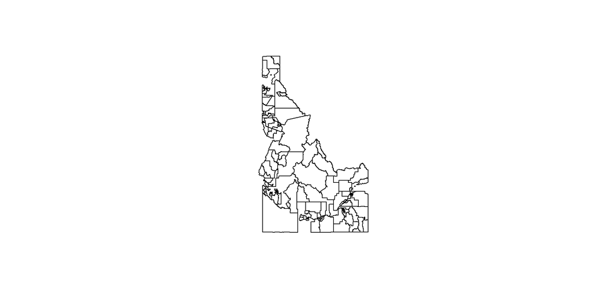

```r
plot(st_geometry(cdc.idaho))
```

## Adding Functions

4. Calculate distance from hospitals

```r
nearest.hosp <- st_nearest_feature(cdc.idaho, hospital.sf.proj)
str(nearest.hosp)
```

```
 int [1:191] 6 45 45 45 3 3 3 3 6 3 ...
```

```r
nearest.hosp.sf <- hospital.sf.proj[nearest.hosp,]
hospital.dist <- st_distance(cdc.idaho, nearest.hosp.sf, by_element = TRUE)
str(hospital.dist)
```

```
 Units: [m] num [1:191] 29414 46610 39432 32817 23548 ...
```

## Adding Functions

```r
cdc.idaho.hosp <- cdc.idaho %>%
  mutate(., disthosp = hospital.dist)

cdc.furthest <- cdc.idaho.hosp %>%
  slice_max(., n=10, order_by= disthosp)

head(cdc.furthest$disthosp)
```

```
Units: [m]
[1] 94622.55 83296.77 80916.73 70646.03 70292.69 69877.25
```